# Pleural-16x-Dilution01 proteomics of pleural infection

Results from Olink Target 96 Inflammation panel

Paul Yousefi

13 July 2026

# Protein measurements

For the moment, all measured proteins have been retained for analysis.

See pleural-16x-dilution01metaboprep_qc_report.html for full details.

# Phenotype information

The below phenotypic information was available on participants:

```
> tibble [88 × 56] (S3: tbl_df/tbl/data.frame)
>  $ patient.id                                         : chr [1:88] "C66ME" "C72GS" "C96JC" "C98MS" ...
>  $ age                                                : num [1:88] 91 77 58 32 73 43 95 59 86 21 ...
>  $ female                                             : num [1:88] 1 0 0 0 0 0 1 1 0 0 ...
>  $ infect.fct                                         : Factor w/ 3 levels "control","inter",..: 2 3 3 3 3 2 1 3 3 1 ...
>  $ infect.num                                         : num [1:88] 2 3 3 3 3 2 1 3 3 1 ...
>  $ infect.bi                                          : num [1:88] 0 1 1 1 1 0 0 1 1 0 ...
>  $ final.diagnosis.1                                  : chr [1:88] "X/infection/CPPE" "X/infection/utrue" "X/infection/bacterial" "X/infection/utrue" ...
>  $ paired.blood                                       : chr [1:88] "C66ME" "C72GS" "C96JC" "C98MS" ...
>  $ sex                                                : chr [1:88] "Female" "Male" "Male" "Male" ...
>  $ age.at.enrollment                                  : num [1:88] 91 77 58 32 73 43 95 59 86 21 ...
>  $ who.ps                                             : chr [1:88] "2" "4" "1" "1" ...
>  $ co.morbidity.present                               : chr [1:88] "Y" "Y" "Y" "Y" ...
>  $ co.morbidity.list                                  : chr [1:88] "CKD, hypertension" "COPD, IHD, hypertension" "asthma" "IVDU" ...
>  $ duration.of..symptoms                              : chr [1:88] "0-1 weeks" "4-6 weeks" "2-4 weeks" "1-2 weeks" ...
>  $ septations                                         : chr [1:88] "Not recorded" "Not recorded" "Not recorded" "Not recorded" ...
>  $ loculations                                        : chr [1:88] "Y" "Y" "Y" "N" ...
>  $ lights.criteria                                    : chr [1:88] "Exudate" "Exudate" "Not recorded" "Exudate" ...
>  $ ph                                                 : chr [1:88] "7.45" "7.38" "7.2430000000000003" "7.117" ...
>  $ crp                                                : chr [1:88] "240" "398" "47" "429" ...
>  $ wcc                                                : chr [1:88] "13.5" "15" "9.3000000000000007" "19.7" ...
>  $ neutrophils                                        : chr [1:88] "11.1" "12.1" "6.8" "17.8" ...
>  $ nlr                                                : chr [1:88] "8.5399999999999991" "5.5" "4.8600000000000003" "13.69" ...
>  $ pf.culture                                         : chr [1:88] "No growth" "No growth" "Positive" "No growth" ...
>  $ organism.isolated                                  : chr [1:88] "0" "0" "Coliforms" "0" ...
>  $ hospital.los                                       : chr [1:88] "26" "15" "21" "35" ...
>  $ chest.drain.insertion                              : chr [1:88] "Y" "Y" "Y" "Y" ...
>  $ lytics                                             : chr [1:88] "N" "N" "N" "N" ...
>  $ surgery                                            : chr [1:88] "N" "N" "Y" "N" ...
>  $ study.enter.date                                   : POSIXct[1:88], format: "2009-08-03" "2009-08-10" ...
>  $ death.date                                         : chr [1:88] "43131" "40069" "45583" "43451" ...
>  $ mortality..3m.                                     : num [1:88] 0 1 0 0 0 0 0 1 0 0 ...
>  $ mortality..1yr.                                    : num [1:88] 0 1 0 0 1 0 1 1 0 0 ...
>  $ composite.outcome..lytics..surgery.or..3m.mortality: num [1:88] 0 1 1 0 0 0 0 1 0 0 ...
>  $ notes                                              : chr [1:88] NA NA NA NA ...
>  $ infect.bi.new                                      : num [1:88] 0 1 1 1 1 0 0 1 1 0 ...
>  $ comp.out                                           : num [1:88] 0 1 1 0 0 0 0 1 0 0 ...
>  $ product                                            : chr [1:88] "TARGET96" "TARGET96" "TARGET96" "TARGET96" ...
>  $ panelversion                                       : int [1:88] 3028 3028 3028 3028 3028 3028 3028 3028 3028 3028 ...
>  $ plateid                                            : chr [1:88] "GB390725-RB_1_16" "GB390725-RB_1_16" "GB390725-RB_1_16" "GB390725-RB_1_16" ...
>  $ wellid                                             : chr [1:88] "A1" "E6" "A2" "E7" ...
>  $ sampletype                                         : chr [1:88] "SAMPLE" "SAMPLE" "SAMPLE" "SAMPLE" ...
>  $ ct                                                 : num [1:88] 11 15.17 10.92 12.34 9.12 ...
>  $ lodnpx                                             : num [1:88] -6.79 -6.79 -6.79 -6.79 -6.79 ...
>  $ belowlod                                           : logi [1:88] FALSE FALSE FALSE FALSE FALSE FALSE ...
>  $ sampleqc                                           : chr [1:88] "PASS" "PASS" "WARN" "PASS" ...
>  $ assayqc                                            : chr [1:88] "PASS" "PASS" "PASS" "PASS" ...
>  $ softwareversion                                    : chr [1:88] "2.2.1" "2.2.1" "2.2.1" "2.2.1" ...
>  $ softwarename                                       : chr [1:88] "NPX Signature" "NPX Signature" "NPX Signature" "NPX Signature" ...
>  $ assaytype                                          : chr [1:88] "assay" "assay" "assay" "assay" ...
>  $ ipcnormalizednpx                                   : num [1:88] 12.3 8.22 13.3 10.93 14.44 ...
>  $ lodipcnormalizednpx                                : num [1:88] 2.13 2.13 2.13 2.13 2.13 ...
>  $ qcdeviationdetctrl                                 : num [1:88] -0.00823 -0.01683 1.12402 -0.1085 0.42195 ...
>  $ qcdeviationincctrl                                 : num [1:88] 0.1451 0.0558 -1.4417 -0.0535 -0.3359 ...
>  $ reason_excluded                                    : logi [1:88] NA NA NA NA NA NA ...
>  $ excluded                                           : logi [1:88] FALSE FALSE FALSE FALSE FALSE FALSE ...
>  $ plate                                              : Factor w/ 1 level "GB390725-RB_1_16": 1 1 1 1 1 1 1 1 1 1 ...
```

Participant age, sex, and infection status are shown below. As is the `final.diagnosis.1` variable that was used to derive the infection status variable, `infect`.

```
>
>                         level                 Overall
>   n                                              88
>   age (mean (SD))                             64.25 (17.14)
>   female (%)            0                        65 ( 73.9)
>                         1                        23 ( 26.1)
>   plate (%)             GB390725-RB_1_16         88 (100.0)
>   infect.fct (%)        control                  11 ( 19.3)
>                         inter                    17 ( 29.8)
>                         case                     29 ( 50.9)
>   infect.num (%)        1                        11 ( 19.3)
>                         2                        17 ( 29.8)
>                         3                        29 ( 50.9)
>   infect.bi (%)         0                        28 ( 49.1)
>                         1                        29 ( 50.9)
>   comp.out (%)          0                        34 ( 59.6)
>                         1                        23 ( 40.4)
>   infect.bi.new (%)     0                        37 ( 56.1)
>                         1                        29 ( 43.9)
>   final.diagnosis.1 (%) M/breast                  1 (  1.1)
>                         M/haem                    1 (  1.1)
>                         M/lung/adeno              1 (  1.1)
>                         M/lung/small              1 (  1.1)
>                         M/meso/epithelioid        4 (  4.5)
>                         M/meso/sarcomatoid        4 (  4.5)
>                         M/renal                   1 (  1.1)
>                         M/skin                    1 (  1.1)
>                         X/cardiac/u               2 (  2.3)
>                         X/hepatic/u               4 (  4.5)
>                         X/infection/bacterial    12 ( 13.6)
>                         X/infection/CPPE         17 ( 19.3)
>                         X/infection/SPE          11 ( 12.5)
>                         X/infection/utrue        17 ( 19.3)
>                         X/inflam/BAPE             8 (  9.1)
>                         X/renal/u                 3 (  3.4)
```

```
>
>      ### Summary of continuous variables ###
>
> strata: Overall
>      n miss p.miss mean sd median p25 p75 min max skew kurt
> age 88    0      0   64 17     68  57  76  18  95 -0.7  0.2
>
> =======================================================================================
>
>      ### Summary of categorical variables ###
>
> strata: Overall
>                var  n miss p.miss                 level freq percent
>             female 88    0    0.0                     0   65    73.9
>                                                       1   23    26.1
>
>              plate 88    0    0.0      GB390725-RB_1_16   88   100.0
>
>         infect.fct 88   31   35.2               control   11    19.3
>                                                   inter   17    29.8
>                                                    case   29    50.9
>
>         infect.num 88   31   35.2                     1   11    19.3
>                                                       2   17    29.8
>                                                       3   29    50.9
>
>          infect.bi 88   31   35.2                     0   28    49.1
>                                                       1   29    50.9
>
>           comp.out 88   31   35.2                     0   34    59.6
>                                                       1   23    40.4
>
>      infect.bi.new 88   22   25.0                     0   37    56.1
>                                                       1   29    43.9
>
>  final.diagnosis.1 88    0    0.0              M/breast    1     1.1
>                                                  M/haem    1     1.1
>                                            M/lung/adeno    1     1.1
>                                            M/lung/small    1     1.1
>                                      M/meso/epithelioid    4     4.5
```

[output cut: 37 more lines]

```
>          3.4
>          4.5
>          9.1
>         13.6
>         14.8
>         15.9
>         18.2
>         22.7
>         36.4
>         55.7
>         68.2
>         87.5
>         96.6
>        100.0
>
```

# Protein-wide associations

Phenotypic characteristics of participants described in Phenotype information were examined for association with protein abundances (Protein measurements)

## Models

The formulae of linear models examined are shown in the table below:

| number | model.name | formula | n |
| --- | --- | --- | --- |
| 1 | pleural-16x-dilution01.infect.fct | proteins ~ infect.fct | 57 |
| 2 | pleural-16x-dilution01.infect.num | proteins ~ infect.num | 57 |
| 3 | pleural-16x-dilution01.infect.bi | proteins ~ infect.bi | 57 |
| 4 | pleural-16x-dilution01.comp.out | proteins ~ comp.out | 57 |
| 5 | pleural-16x-dilution01.infect.bi.new | proteins ~ infect.bi.new | 66 |
| 6 | pleural-16x-dilution01.female | proteins ~ female | 88 |
| 7 | pleural-16x-dilution01.age | proteins ~ age | 88 |
| 8 | pleural-16x-dilution01.infect.fct.fulladj | proteins ~ infect.fct + female + age | 57 |
| 9 | pleural-16x-dilution01.infect.num.fulladj | proteins ~ infect.num + female + age | 57 |
| 10 | pleural-16x-dilution01.infect.bi.fulladj | proteins ~ infect.bi + female + age | 57 |
| 11 | pleural-16x-dilution01.comp.out.fulladj | proteins ~ comp.out + female + age | 57 |
| 12 | pleural-16x-dilution01.infect.bi.new.fulladj | proteins ~ infect.bi.new + female + age | 66 |

## QQ plots

```
> $`pleural-16x-dilution01.infect.fct`
```

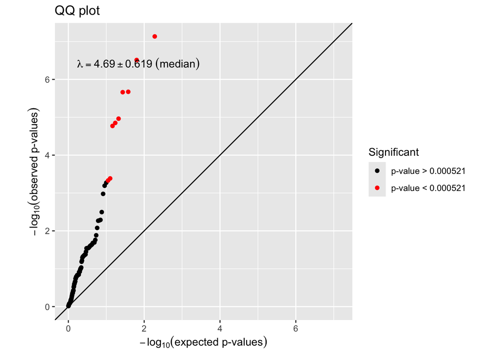

```
>
> $`pleural-16x-dilution01.infect.num`
```

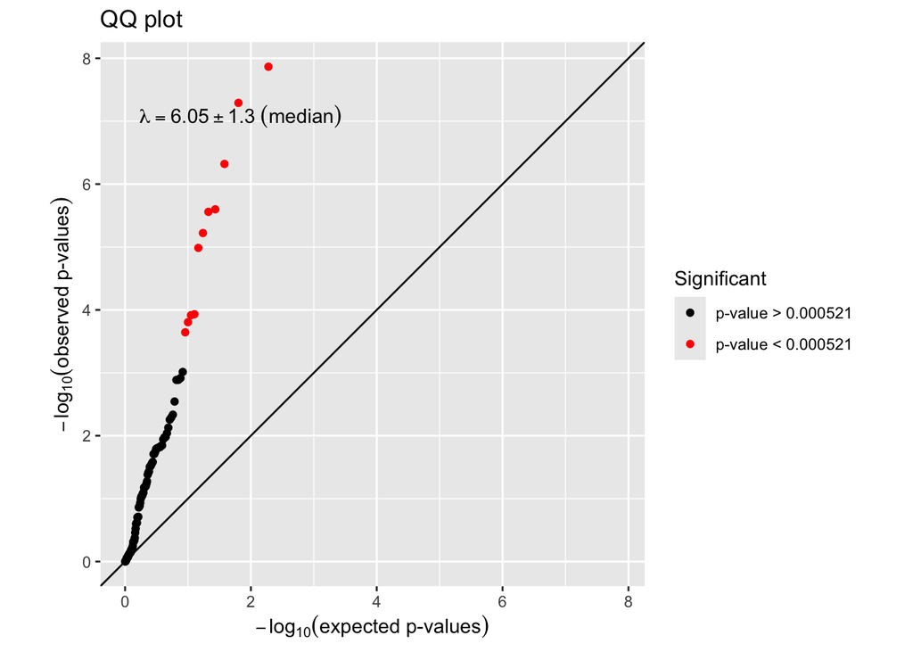

```
>
> $`pleural-16x-dilution01.infect.bi`
```

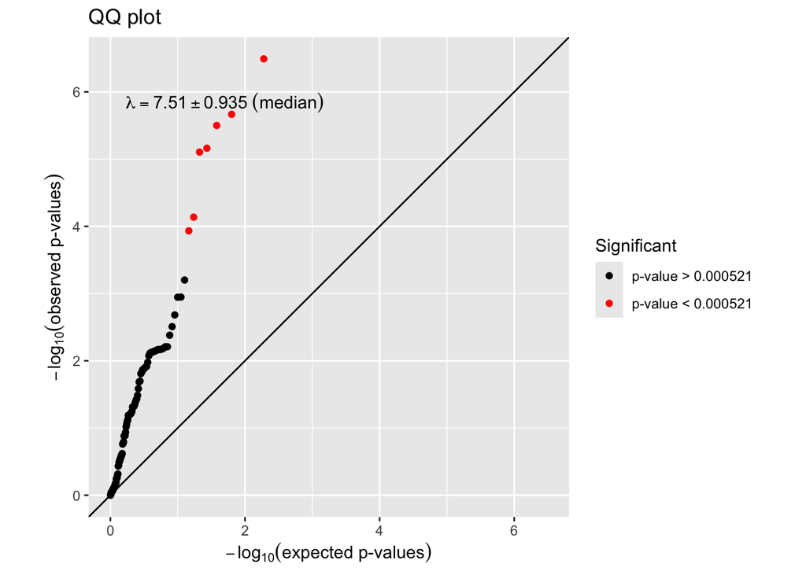

```
>
> $`pleural-16x-dilution01.comp.out`
```

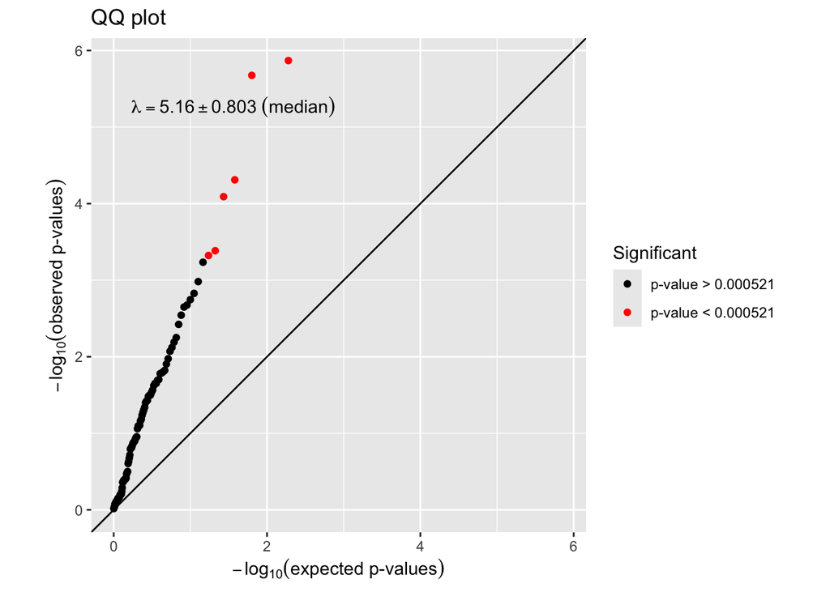

```
>
> $`pleural-16x-dilution01.infect.bi.new`
```

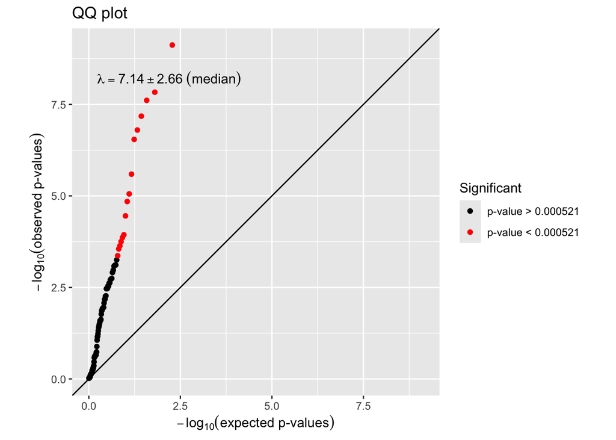

```
>
> $`pleural-16x-dilution01.female`
```

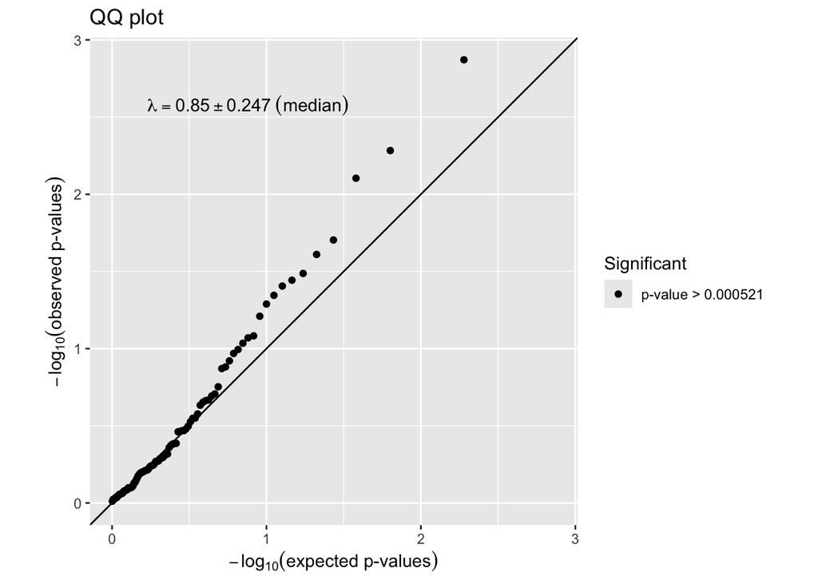

```
>
> $`pleural-16x-dilution01.age`
```

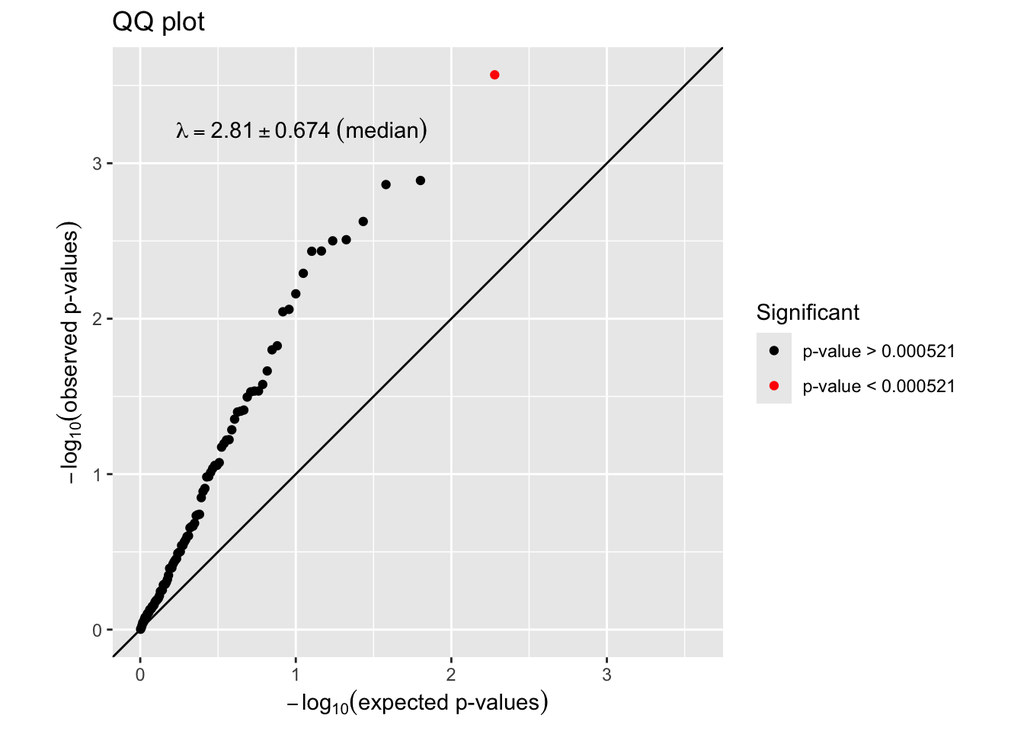

```
>
> $`pleural-16x-dilution01.infect.fct.fulladj`
```

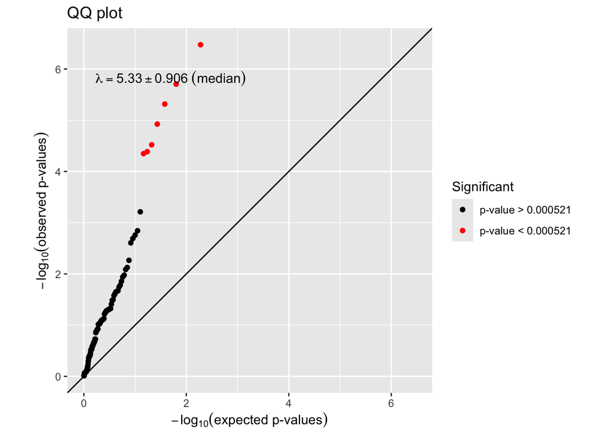

```
>
> $`pleural-16x-dilution01.infect.num.fulladj`
```

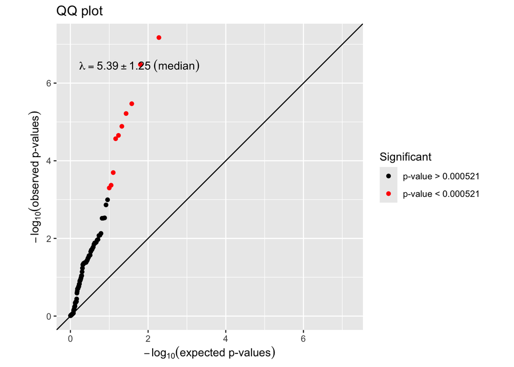

```
>
> $`pleural-16x-dilution01.infect.bi.fulladj`
```

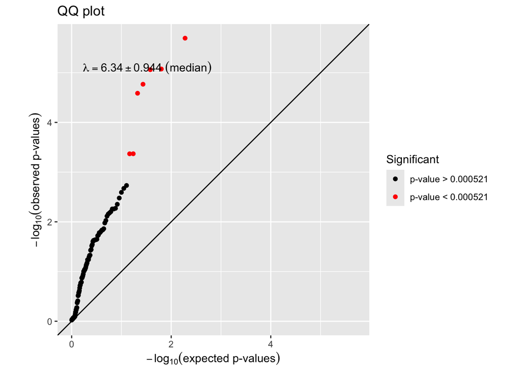

```
>
> $`pleural-16x-dilution01.comp.out.fulladj`
```

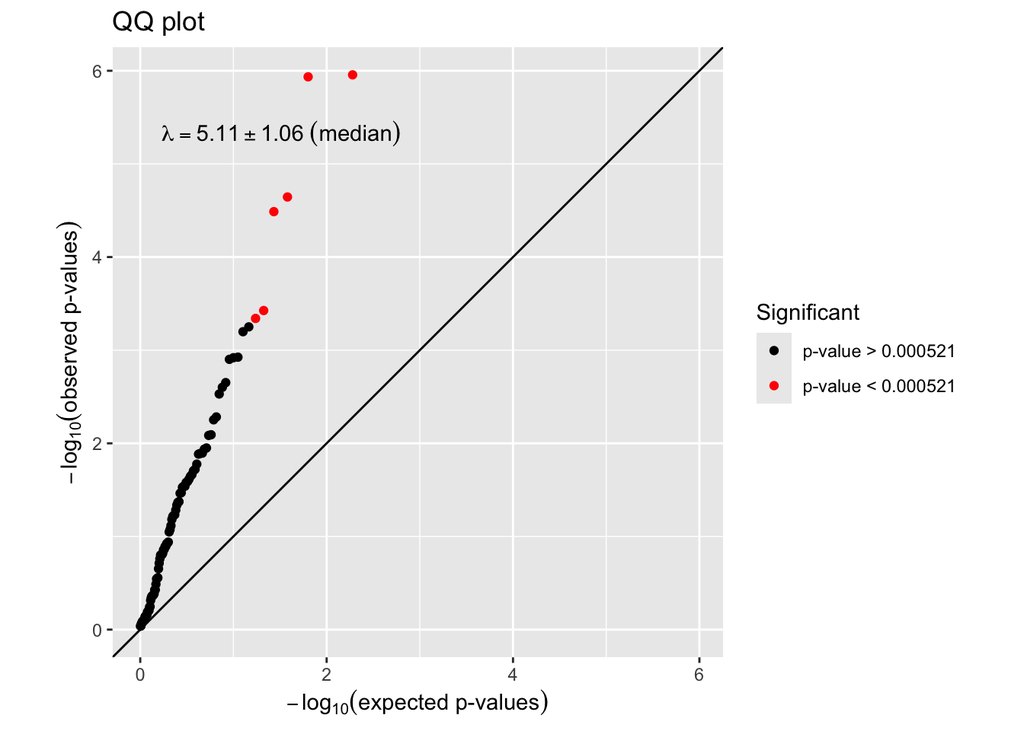

```
>
> $`pleural-16x-dilution01.infect.bi.new.fulladj`
```

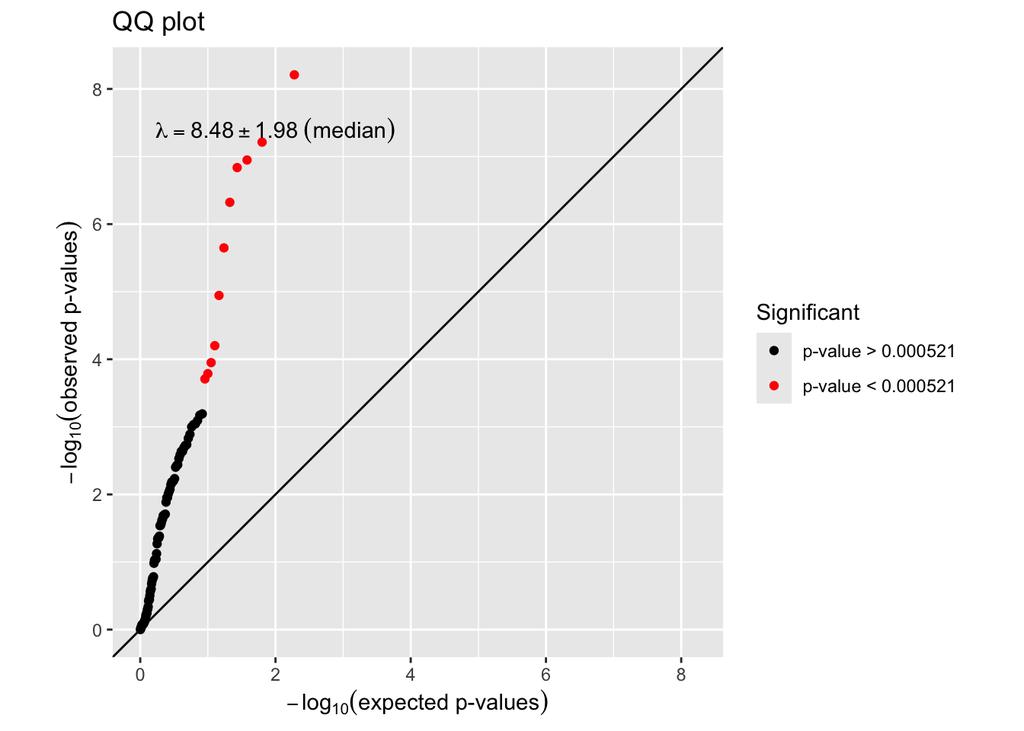

## Volcano plots

```
> $`pleural-16x-dilution01.infect.fct`
```

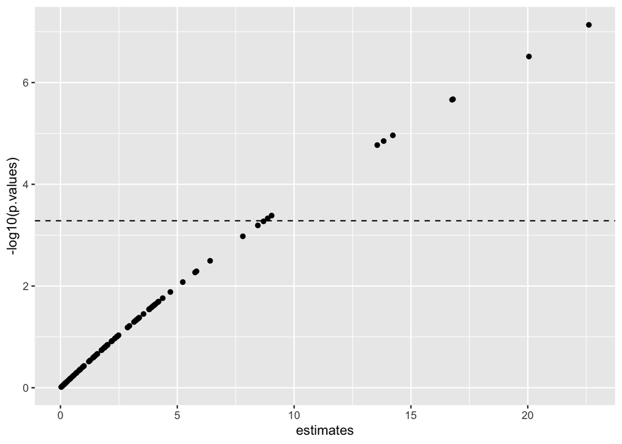

```
>
> $`pleural-16x-dilution01.infect.num`
```

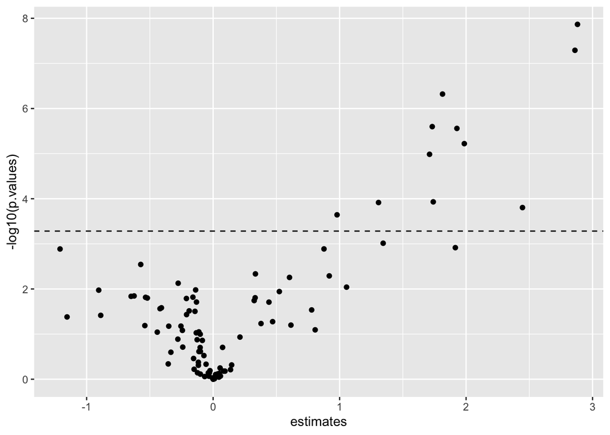

```
>
> $`pleural-16x-dilution01.infect.bi`
```

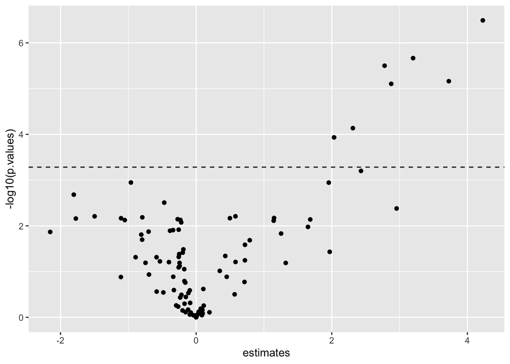

```
>
> $`pleural-16x-dilution01.comp.out`
```

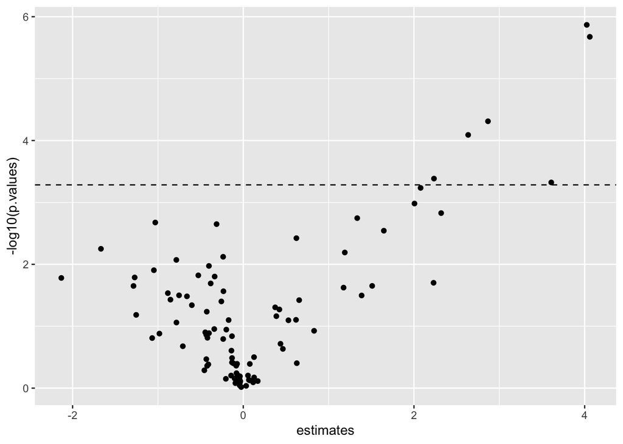

```
>
> $`pleural-16x-dilution01.infect.bi.new`
```

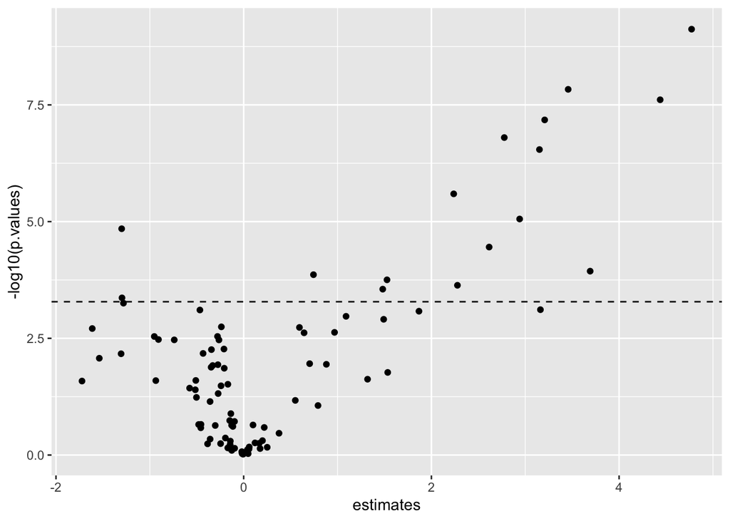

```
>
> $`pleural-16x-dilution01.female`
```

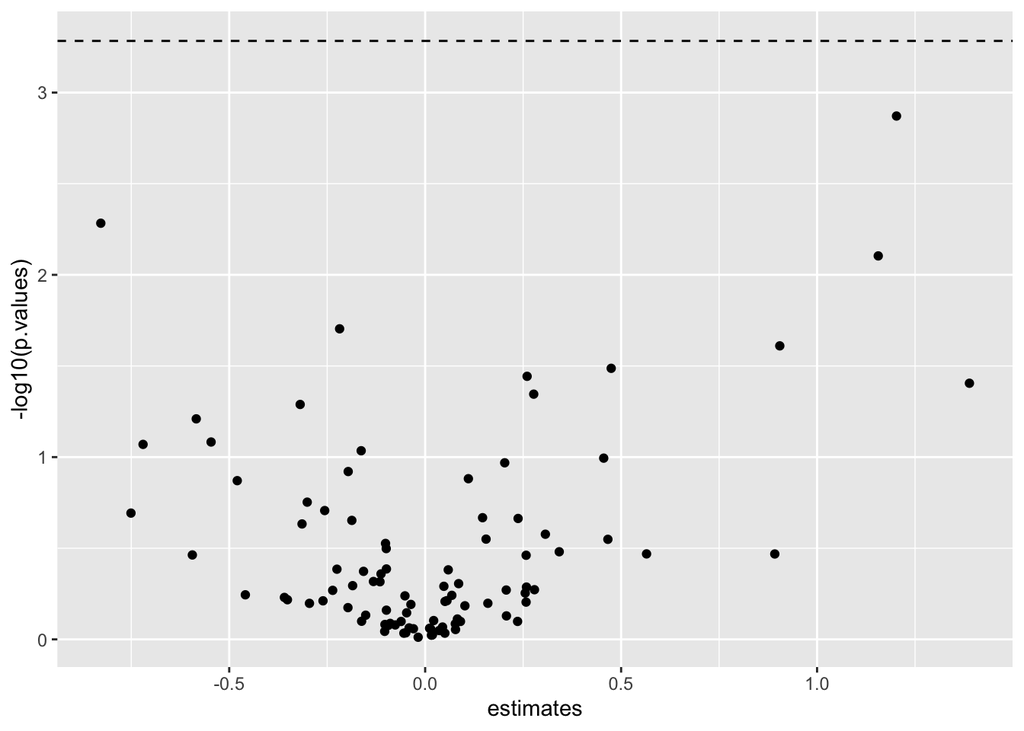

```
>
> $`pleural-16x-dilution01.age`
```

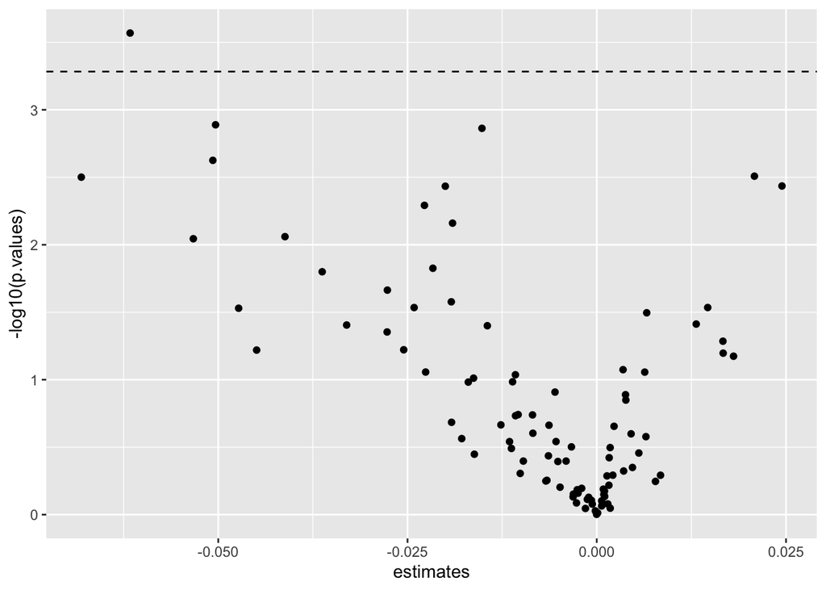

```
>
> $`pleural-16x-dilution01.infect.fct.fulladj`
```

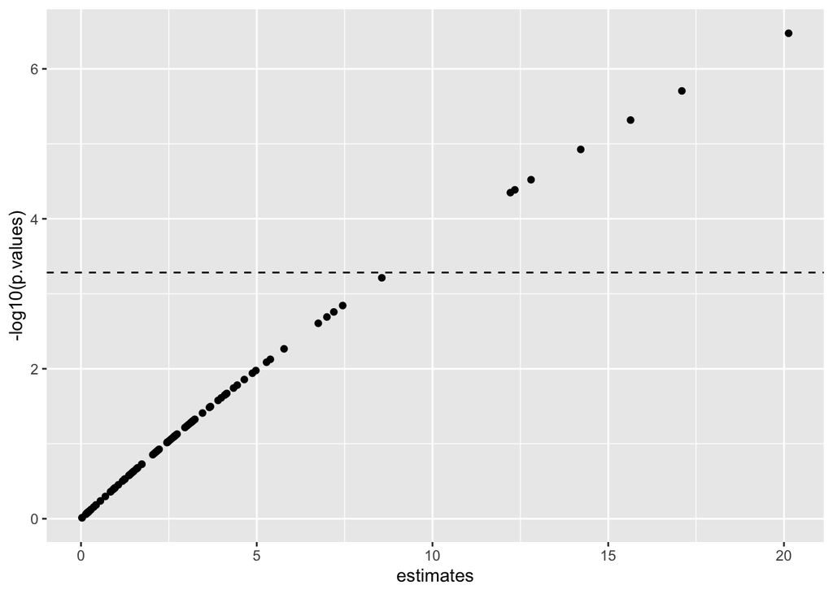

```
>
> $`pleural-16x-dilution01.infect.num.fulladj`
```

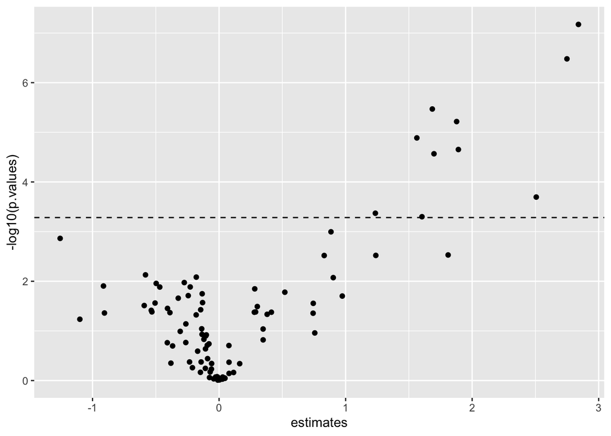

```
>
> $`pleural-16x-dilution01.infect.bi.fulladj`
```

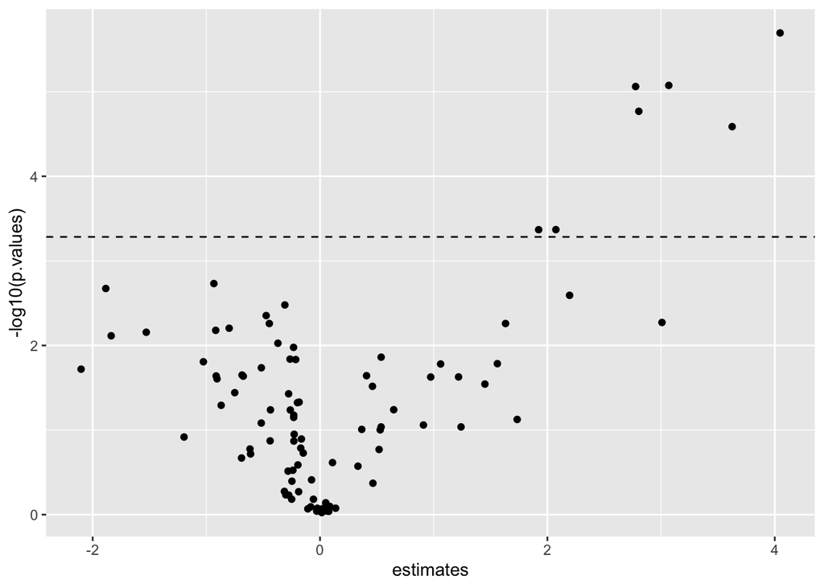

```
>
> $`pleural-16x-dilution01.comp.out.fulladj`
```

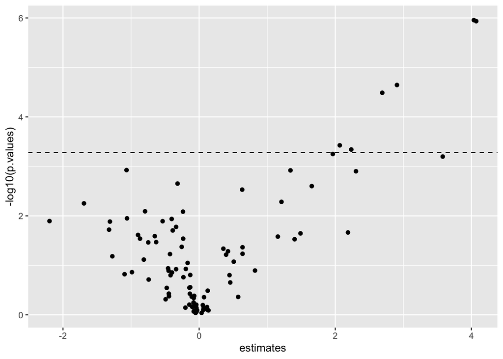

```
>
> $`pleural-16x-dilution01.infect.bi.new.fulladj`
```

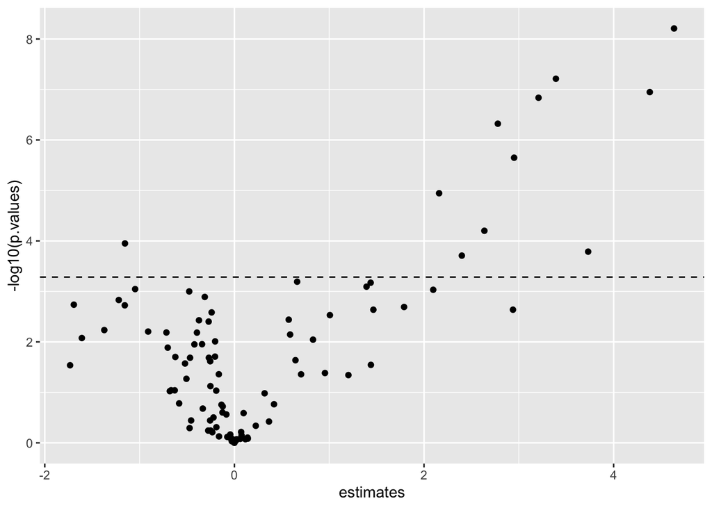

## Hit counts per model

| number | model.name | formula | n | bonf.sig | fdr.sig |
| --- | --- | --- | --- | --- | --- |
| 1 | pleural-16x-dilution01.infect.fct | proteins ~ infect.fct | 57 | 9 | NA |
| 2 | pleural-16x-dilution01.infect.num | proteins ~ infect.num | 57 | 11 | NA |
| 3 | pleural-16x-dilution01.infect.bi | proteins ~ infect.bi | 57 | 7 | NA |
| 4 | pleural-16x-dilution01.comp.out | proteins ~ comp.out | 57 | 6 | NA |
| 5 | pleural-16x-dilution01.infect.bi.new | proteins ~ infect.bi.new | 66 | 16 | NA |
| 6 | pleural-16x-dilution01.female | proteins ~ female | 88 | 0 | NA |
| 7 | pleural-16x-dilution01.age | proteins ~ age | 88 | 1 | NA |
| 8 | pleural-16x-dilution01.infect.fct.fulladj | proteins ~ infect.fct + female + age | 57 | 7 | NA |
| 9 | pleural-16x-dilution01.infect.num.fulladj | proteins ~ infect.num + female + age | 57 | 10 | NA |
| 10 | pleural-16x-dilution01.infect.bi.fulladj | proteins ~ infect.bi + female + age | 57 | 7 | NA |
| 11 | pleural-16x-dilution01.comp.out.fulladj | proteins ~ comp.out + female + age | 57 | 6 | NA |
| 12 | pleural-16x-dilution01.infect.bi.new.fulladj | proteins ~ infect.bi.new + female + age | 66 | 11 | NA |

## Top hits

$`pleural-16x-dilution01.infect.fct`

| feature_id | uniprot | gene | f | p.value | infect.fctinter.estimate | infect.fctinter.se | infect.fctinter.t | infect.fctinter.p.value | infect.fctcase.estimate | infect.fctcase.se | infect.fctcase.t | infect.fctcase.p.value | n | p.adjust |
| --- | --- | --- | --- | --- | --- | --- | --- | --- | --- | --- | --- | --- | --- | --- |
| OID00471 | P10145 | IL8 | 22.614 | 7.335583e-08 | 3.733 | 0.981 | 3.805 | 3.640735e-04 | 5.992 | 0.898 | 6.673 | 1.395963e-08 | 57 | 6.968804e-06 |
| OID00494 | P13725 | OSM | 20.050 | 3.074080e-07 | 2.138 | 1.032 | 2.072 | 4.306663e-02 | 5.526 | 0.944 | 5.852 | 2.943738e-07 | 57 | 2.920376e-05 |
| OID00547 | P15018 | LIF | 16.799 | 2.124653e-06 | 3.091 | 0.726 | 4.257 | 8.301649e-05 | 3.833 | 0.664 | 5.768 | 4.009411e-07 | 57 | 2.018420e-04 |
| OID00541 | P80511 | EN-RAGE | 16.760 | 2.176703e-06 | 2.453 | 0.721 | 3.403 | 1.260831e-03 | 3.800 | 0.660 | 5.762 | 4.088819e-07 | 57 | 2.067868e-04 |
| OID00506 | O43557 | TNFSF14 | 14.226 | 1.089297e-05 | 0.698 | 0.886 | 0.788 | 4.339799e-01 | 3.623 | 0.811 | 4.470 | 4.047205e-05 | 57 | 1.034832e-03 |
| OID00560 | P00813 | ADA | 13.833 | 1.411210e-05 | 1.357 | 0.839 | 1.617 | 1.117049e-01 | 3.701 | 0.768 | 4.818 | 1.218035e-05 | 57 | 1.340650e-03 |
| OID00493 | P01583 | IL-1 alpha | 13.558 | 1.693923e-05 | 0.535 | 0.786 | 0.681 | 4.989662e-01 | 3.104 | 0.719 | 4.314 | 6.860479e-05 | 57 | 1.609227e-03 |
| OID00532 | P10147 | CCL3 | 9.037 | 4.118669e-04 | 0.676 | 0.717 | 0.944 | 3.495232e-01 | 2.445 | 0.656 | 3.728 | 4.645191e-04 | 57 | 3.912736e-02 |
| OID00520 | P42830 | CXCL5 | 8.870 | 4.667977e-04 | 3.785 | 1.363 | 2.777 | 7.529932e-03 | 5.254 | 1.248 | 4.212 | 9.666181e-05 | 57 | 4.434578e-02 |
| OID00472 | P15692 | VEGFA | 8.690 | 5.344956e-04 | 1.620 | 0.560 | 2.896 | 5.450043e-03 | 2.133 | 0.512 | 4.165 | 1.128048e-04 | 57 | 5.077708e-02 |

$`pleural-16x-dilution01.infect.num`

| feature_id | uniprot | gene | estimate | se | t | p.value | n | p.adjust |
| --- | --- | --- | --- | --- | --- | --- | --- | --- |
| OID00471 | P10145 | IL8 | 2.881 | 0.433 | 6.659 | 1.363466e-08 | 57 | 1.295293e-06 |
| OID00494 | P13725 | OSM | 2.861 | 0.454 | 6.307 | 5.122009e-08 | 57 | 4.865908e-06 |
| OID00541 | P80511 | EN-RAGE | 1.814 | 0.318 | 5.706 | 4.780784e-07 | 57 | 4.541745e-05 |
| OID00547 | P15018 | LIF | 1.732 | 0.330 | 5.251 | 2.518867e-06 | 57 | 2.392924e-04 |
| OID00560 | P00813 | ADA | 1.927 | 0.369 | 5.225 | 2.760343e-06 | 57 | 2.622326e-04 |
| OID00506 | O43557 | TNFSF14 | 1.986 | 0.396 | 5.009 | 6.003546e-06 | 57 | 5.703369e-04 |
| OID00493 | P01583 | IL-1 alpha | 1.711 | 0.352 | 4.855 | 1.033909e-05 | 57 | 9.822136e-04 |
| OID00485 | Q16552 | IL-17A | 1.740 | 0.420 | 4.148 | 1.170985e-04 | 57 | 1.112436e-02 |
| OID00532 | P10147 | CCL3 | 1.308 | 0.316 | 4.138 | 1.212320e-04 | 57 | 1.151704e-02 |
| OID00520 | P42830 | CXCL5 | 2.446 | 0.602 | 4.060 | 1.568651e-04 | 57 | 1.490219e-02 |

$`pleural-16x-dilution01.infect.bi`

| feature_id | uniprot | gene | estimate | se | t | p.value | n | p.adjust |
| --- | --- | --- | --- | --- | --- | --- | --- | --- |
| OID00494 | P13725 | OSM | 4.228 | 0.727 | 5.812 | 3.225694e-07 | 57 | 3.064410e-05 |
| OID00506 | O43557 | TNFSF14 | 3.200 | 0.604 | 5.294 | 2.155910e-06 | 57 | 2.048114e-04 |
| OID00493 | P01583 | IL-1 alpha | 2.779 | 0.536 | 5.188 | 3.159695e-06 | 57 | 3.001710e-04 |
| OID00471 | P10145 | IL8 | 3.726 | 0.750 | 4.970 | 6.888339e-06 | 57 | 6.543922e-04 |
| OID00560 | P00813 | ADA | 2.876 | 0.583 | 4.933 | 7.853574e-06 | 57 | 7.460895e-04 |
| OID00541 | P80511 | EN-RAGE | 2.311 | 0.539 | 4.289 | 7.306987e-05 | 57 | 6.941637e-03 |
| OID00532 | P10147 | CCL3 | 2.034 | 0.490 | 4.149 | 1.166438e-04 | 57 | 1.108116e-02 |
| OID00485 | Q16552 | IL-17A | 2.431 | 0.670 | 3.626 | 6.293881e-04 | 57 | 5.979187e-02 |
| OID00551 | O15444 | CCL25 | -0.962 | 0.280 | -3.437 | 1.128590e-03 | 57 | 1.072160e-01 |
| OID00547 | P15018 | LIF | 1.956 | 0.569 | 3.435 | 1.134476e-03 | 57 | 1.077752e-01 |

$`pleural-16x-dilution01.comp.out`

| feature_id | uniprot | gene | estimate | se | t | p.value | n | p.adjust |
| --- | --- | --- | --- | --- | --- | --- | --- | --- |
| OID00471 | P10145 | IL8 | 4.025 | 0.742 | 5.422 | 1.354268e-06 | 57 | 1.286554e-04 |
| OID00494 | P13725 | OSM | 4.060 | 0.766 | 5.300 | 2.111369e-06 | 57 | 2.005801e-04 |
| OID00506 | O43557 | TNFSF14 | 2.867 | 0.650 | 4.408 | 4.886300e-05 | 57 | 4.641985e-03 |
| OID00560 | P00813 | ADA | 2.635 | 0.619 | 4.258 | 8.112611e-05 | 57 | 7.706980e-03 |
| OID00493 | P01583 | IL-1 alpha | 2.234 | 0.594 | 3.761 | 4.122062e-04 | 57 | 3.915959e-02 |
| OID00520 | P42830 | CXCL5 | 3.609 | 0.971 | 3.716 | 4.754452e-04 | 57 | 4.516730e-02 |
| OID00541 | P80511 | EN-RAGE | 2.078 | 0.569 | 3.651 | 5.827359e-04 | 57 | 5.535991e-02 |
| OID00547 | P15018 | LIF | 2.006 | 0.579 | 3.463 | 1.042508e-03 | 57 | 9.903823e-02 |
| OID00485 | Q16552 | IL-17A | 2.318 | 0.693 | 3.345 | 1.486640e-03 | 57 | 1.412308e-01 |
| OID00472 | P15692 | VEGFA | 1.335 | 0.407 | 3.282 | 1.793852e-03 | 57 | 1.704159e-01 |

$`pleural-16x-dilution01.infect.bi.new`

| feature_id | uniprot | gene | estimate | se | t | p.value | n | p.adjust |
| --- | --- | --- | --- | --- | --- | --- | --- | --- |
| OID00494 | P13725 | OSM | 4.772 | 0.661 | 7.222 | 7.563694e-10 | 66 | 7.185509e-08 |
| OID00506 | O43557 | TNFSF14 | 3.457 | 0.533 | 6.486 | 1.470545e-08 | 66 | 1.397018e-06 |
| OID00471 | P10145 | IL8 | 4.438 | 0.698 | 6.358 | 2.456455e-08 | 66 | 2.333632e-06 |
| OID00560 | P00813 | ADA | 3.207 | 0.525 | 6.107 | 6.635546e-08 | 66 | 6.303768e-06 |
| OID00493 | P01583 | IL-1 alpha | 2.777 | 0.472 | 5.886 | 1.585350e-07 | 66 | 1.506083e-05 |
| OID00541 | P80511 | EN-RAGE | 3.151 | 0.550 | 5.735 | 2.862885e-07 | 66 | 2.719741e-05 |
| OID00532 | P10147 | CCL3 | 2.238 | 0.433 | 5.165 | 2.545983e-06 | 66 | 2.418684e-04 |
| OID00547 | P15018 | LIF | 2.940 | 0.608 | 4.832 | 8.797895e-06 | 66 | 8.358000e-04 |
| OID00551 | O15444 | CCL25 | -1.300 | 0.277 | -4.701 | 1.422021e-05 | 66 | 1.350920e-03 |
| OID00485 | Q16552 | IL-17A | 2.615 | 0.588 | 4.450 | 3.511544e-05 | 66 | 3.335966e-03 |

$`pleural-16x-dilution01.female`

| feature_id | uniprot | gene | estimate | se | t | p.value | n | p.adjust |
| --- | --- | --- | --- | --- | --- | --- | --- | --- |
| OID00512 | Q9NSA1 | FGF-21 | 1.203 | 0.363 | 3.315 | 1.344895e-03 | 88 | 1.277651e-01 |
| OID00481 | P00749 | uPA | -0.828 | 0.289 | -2.867 | 5.208942e-03 | 88 | 4.948495e-01 |
| OID00496 | P09341 | CXCL1 | 1.156 | 0.425 | 2.721 | 7.872659e-03 | 88 | 7.479026e-01 |
| OID00525 | P35225 | IL13 | -0.218 | 0.092 | -2.375 | 1.977665e-02 | 88 | 1.000000e+00 |
| OID00534 | P80162 | CXCL6 | 0.905 | 0.395 | 2.289 | 2.453072e-02 | 88 | 1.000000e+00 |
| OID00552 | P78423 | CX3CL1 | 0.475 | 0.218 | 2.173 | 3.257581e-02 | 87 | 1.000000e+00 |
| OID00557 | P50225 | ST1A1 | 0.260 | 0.122 | 2.130 | 3.603665e-02 | 88 | 1.000000e+00 |
| OID00513 | Q99731 | CCL19 | 1.389 | 0.664 | 2.093 | 3.933568e-02 | 88 | 1.000000e+00 |
| OID00561 | P01374 | TNFB | 0.277 | 0.136 | 2.033 | 4.515042e-02 | 88 | 1.000000e+00 |
| OID00554 | P20783 | NT-3 | -0.319 | 0.161 | -1.975 | 5.142273e-02 | 88 | 1.000000e+00 |

$`pleural-16x-dilution01.age`

| feature_id | uniprot | gene | estimate | se | t | p.value | n | p.adjust |
| --- | --- | --- | --- | --- | --- | --- | --- | --- |
| OID00547 | P15018 | LIF | -0.062 | 0.016 | -3.799 | 2.698957e-04 | 88 | 2.564009e-02 |
| OID00485 | Q16552 | IL-17A | -0.050 | 0.015 | -3.327 | 1.291471e-03 | 88 | 1.226897e-01 |
| OID00488 | P50591 | TRAIL | -0.015 | 0.005 | -3.308 | 1.371605e-03 | 88 | 1.303025e-01 |
| OID00541 | P80511 | EN-RAGE | -0.051 | 0.016 | -3.133 | 2.369099e-03 | 88 | 2.250644e-01 |
| OID00551 | O15444 | CCL25 | 0.021 | 0.007 | 3.043 | 3.103909e-03 | 88 | 2.948713e-01 |
| OID00556 | P78556 | CCL20 | -0.068 | 0.022 | -3.038 | 3.156403e-03 | 88 | 2.998582e-01 |
| OID00491 | P28325 | CST5 | 0.024 | 0.008 | 2.987 | 3.670155e-03 | 88 | 3.486647e-01 |
| OID00503 | P01135 | TGF-alpha | -0.020 | 0.007 | -2.986 | 3.683589e-03 | 88 | 3.499410e-01 |
| OID00521 | O14788 | TRANCE | -0.023 | 0.008 | -2.874 | 5.106079e-03 | 88 | 4.850775e-01 |
| OID00524 | Q13007 | IL-24 | -0.019 | 0.007 | -2.767 | 6.916037e-03 | 88 | 6.570235e-01 |

$`pleural-16x-dilution01.infect.fct.fulladj`

| feature_id | uniprot | gene | f | p.value | infect.fctinter.estimate | infect.fctinter.se | infect.fctinter.t | infect.fctinter.p.value | infect.fctcase.estimate | infect.fctcase.se | infect.fctcase.t | infect.fctcase.p.value | n | p.adjust |
| --- | --- | --- | --- | --- | --- | --- | --- | --- | --- | --- | --- | --- | --- | --- |
| OID00471 | P10145 | IL8 | 20.132 | 3.352248e-07 | 3.716 | 0.998 | 3.724 | 4.834265e-04 | 5.901 | 0.934 | 6.322 | 5.959049e-08 | 57 | 3.184636e-05 |
| OID00494 | P13725 | OSM | 17.095 | 1.969100e-06 | 2.105 | 1.043 | 2.019 | 4.868124e-02 | 5.336 | 0.976 | 5.470 | 1.305927e-06 | 57 | 1.870645e-04 |
| OID00547 | P15018 | LIF | 15.636 | 4.821223e-06 | 3.054 | 0.685 | 4.462 | 4.385587e-05 | 3.502 | 0.640 | 5.469 | 1.306929e-06 | 57 | 4.580162e-04 |
| OID00541 | P80511 | EN-RAGE | 14.217 | 1.187372e-05 | 2.418 | 0.713 | 3.392 | 1.333500e-03 | 3.555 | 0.667 | 5.331 | 2.143001e-06 | 57 | 1.128003e-03 |
| OID00560 | P00813 | ADA | 12.804 | 3.009981e-05 | 1.325 | 0.826 | 1.604 | 1.147806e-01 | 3.616 | 0.773 | 4.678 | 2.101971e-05 | 57 | 2.859482e-03 |
| OID00506 | O43557 | TNFSF14 | 12.343 | 4.107092e-05 | 0.661 | 0.883 | 0.749 | 4.574587e-01 | 3.472 | 0.826 | 4.203 | 1.039203e-04 | 57 | 3.901737e-03 |
| OID00493 | P01583 | IL-1 alpha | 12.216 | 4.476477e-05 | 0.535 | 0.802 | 0.668 | 5.072068e-01 | 3.104 | 0.750 | 4.139 | 1.280674e-04 | 57 | 4.252653e-03 |
| OID00520 | P42830 | CXCL5 | 8.558 | 6.124334e-04 | 3.812 | 1.381 | 2.761 | 7.942045e-03 | 5.342 | 1.292 | 4.137 | 1.291393e-04 | 57 | 5.818117e-02 |
| OID00532 | P10147 | CCL3 | 7.445 | 1.434182e-03 | 0.655 | 0.725 | 0.903 | 3.706539e-01 | 2.324 | 0.678 | 3.427 | 1.200542e-03 | 57 | 1.362473e-01 |
| OID00472 | P15692 | VEGFA | 7.193 | 1.746532e-03 | 1.589 | 0.554 | 2.866 | 5.981522e-03 | 1.947 | 0.519 | 3.754 | 4.399998e-04 | 57 | 1.659206e-01 |

$`pleural-16x-dilution01.infect.num.fulladj`

| feature_id | uniprot | gene | estimate | se | t | p.value | n | p.adjust |
| --- | --- | --- | --- | --- | --- | --- | --- | --- |
| OID00471 | P10145 | IL8 | 2.840 | 0.453 | 6.270 | 6.711696e-08 | 57 | 6.376111e-06 |
| OID00494 | P13725 | OSM | 2.749 | 0.471 | 5.835 | 3.313955e-07 | 57 | 3.148257e-05 |
| OID00541 | P80511 | EN-RAGE | 1.685 | 0.325 | 5.190 | 3.392170e-06 | 57 | 3.222562e-04 |
| OID00560 | P00813 | ADA | 1.877 | 0.374 | 5.025 | 6.074444e-06 | 57 | 5.770722e-04 |
| OID00547 | P15018 | LIF | 1.563 | 0.325 | 4.809 | 1.296351e-05 | 57 | 1.231534e-03 |
| OID00506 | O43557 | TNFSF14 | 1.891 | 0.406 | 4.653 | 2.220760e-05 | 57 | 2.109722e-03 |
| OID00493 | P01583 | IL-1 alpha | 1.698 | 0.370 | 4.596 | 2.705279e-05 | 57 | 2.570015e-03 |
| OID00520 | P42830 | CXCL5 | 2.507 | 0.628 | 3.994 | 2.014956e-04 | 57 | 1.914208e-02 |
| OID00532 | P10147 | CCL3 | 1.235 | 0.329 | 3.760 | 4.261512e-04 | 57 | 4.048436e-02 |
| OID00485 | Q16552 | IL-17A | 1.604 | 0.432 | 3.708 | 5.010841e-04 | 57 | 4.760299e-02 |

$`pleural-16x-dilution01.infect.bi.fulladj`

| feature_id | uniprot | gene | estimate | se | t | p.value | n | p.adjust |
| --- | --- | --- | --- | --- | --- | --- | --- | --- |
| OID00494 | P13725 | OSM | 4.047 | 0.759 | 5.335 | 2.020048e-06 | 57 | 1.919046e-04 |
| OID00506 | O43557 | TNFSF14 | 3.067 | 0.622 | 4.932 | 8.425956e-06 | 57 | 8.004658e-04 |
| OID00493 | P01583 | IL-1 alpha | 2.776 | 0.564 | 4.923 | 8.692294e-06 | 57 | 8.257679e-04 |
| OID00560 | P00813 | ADA | 2.804 | 0.593 | 4.730 | 1.705310e-05 | 57 | 1.620045e-03 |
| OID00471 | P10145 | IL8 | 3.625 | 0.787 | 4.608 | 2.590206e-05 | 57 | 2.460695e-03 |
| OID00541 | P80511 | EN-RAGE | 2.074 | 0.552 | 3.759 | 4.270272e-04 | 57 | 4.056759e-02 |
| OID00532 | P10147 | CCL3 | 1.923 | 0.512 | 3.758 | 4.279270e-04 | 57 | 4.065307e-02 |
| OID00550 | Q14790 | CASP-8 | -0.934 | 0.285 | -3.277 | 1.855313e-03 | 57 | 1.762548e-01 |
| OID00479 | O00300 | OPG | -1.884 | 0.583 | -3.231 | 2.121948e-03 | 57 | 2.015851e-01 |
| OID00485 | Q16552 | IL-17A | 2.195 | 0.693 | 3.167 | 2.554483e-03 | 57 | 2.426758e-01 |

$`pleural-16x-dilution01.comp.out.fulladj`

| feature_id | uniprot | gene | estimate | se | t | p.value | n | p.adjust |
| --- | --- | --- | --- | --- | --- | --- | --- | --- |
| OID00471 | P10145 | IL8 | 4.036 | 0.733 | 5.503 | 1.105246e-06 | 57 | 1.049984e-04 |
| OID00494 | P13725 | OSM | 4.070 | 0.741 | 5.489 | 1.161572e-06 | 57 | 1.103493e-04 |
| OID00506 | O43557 | TNFSF14 | 2.906 | 0.625 | 4.647 | 2.265449e-05 | 57 | 2.152177e-03 |
| OID00560 | P00813 | ADA | 2.690 | 0.592 | 4.542 | 3.254310e-05 | 57 | 3.091595e-03 |
| OID00541 | P80511 | EN-RAGE | 2.066 | 0.544 | 3.800 | 3.751173e-04 | 57 | 3.563614e-02 |
| OID00493 | P01583 | IL-1 alpha | 2.235 | 0.598 | 3.738 | 4.560514e-04 | 57 | 4.332488e-02 |
| OID00547 | P15018 | LIF | 1.964 | 0.535 | 3.671 | 5.618433e-04 | 57 | 5.337511e-02 |
| OID00520 | P42830 | CXCL5 | 3.578 | 0.985 | 3.633 | 6.334414e-04 | 57 | 6.017693e-02 |
| OID05124 | P01732 | CD8A | -1.066 | 0.311 | -3.427 | 1.188612e-03 | 57 | 1.129181e-01 |
| OID00472 | P15692 | VEGFA | 1.342 | 0.392 | 3.422 | 1.204121e-03 | 57 | 1.143915e-01 |

$`pleural-16x-dilution01.infect.bi.new.fulladj`

| feature_id | uniprot | gene | estimate | se | t | p.value | n | p.adjust |
| --- | --- | --- | --- | --- | --- | --- | --- | --- |
| OID00494 | P13725 | OSM | 4.637 | 0.689 | 6.735 | 6.179592e-09 | 66 | 5.870612e-07 |
| OID00506 | O43557 | TNFSF14 | 3.391 | 0.551 | 6.153 | 6.122708e-08 | 66 | 5.816572e-06 |
| OID00471 | P10145 | IL8 | 4.381 | 0.731 | 5.997 | 1.126144e-07 | 66 | 1.069837e-05 |
| OID00560 | P00813 | ADA | 3.208 | 0.541 | 5.931 | 1.457549e-07 | 66 | 1.384671e-05 |
| OID00493 | P01583 | IL-1 alpha | 2.779 | 0.494 | 5.624 | 4.761471e-07 | 66 | 4.523398e-05 |
| OID00541 | P80511 | EN-RAGE | 2.950 | 0.566 | 5.215 | 2.247065e-06 | 66 | 2.134712e-04 |
| OID00532 | P10147 | CCL3 | 2.159 | 0.452 | 4.775 | 1.136451e-05 | 66 | 1.079629e-03 |
| OID00547 | P15018 | LIF | 2.637 | 0.614 | 4.294 | 6.293296e-05 | 66 | 5.978631e-03 |
| OID00551 | O15444 | CCL25 | -1.154 | 0.280 | -4.126 | 1.120667e-04 | 66 | 1.064634e-02 |
| OID00520 | P42830 | CXCL5 | 3.731 | 0.929 | 4.015 | 1.631035e-04 | 66 | 1.549483e-02 |

## IL6 results

$`pleural-16x-dilution01.infect.fct`

|  | feature_id | uniprot | gene | f | p.value | infect.fctinter.estimate | infect.fctinter.se | infect.fctinter.t | infect.fctinter.p.value | infect.fctcase.estimate | infect.fctcase.se | infect.fctcase.t | infect.fctcase.p.value | n | p.adjust |
| --- | --- | --- | --- | --- | --- | --- | --- | --- | --- | --- | --- | --- | --- | --- | --- |
| 15 | OID00482 | P05231 | IL6 | 2.182 | 1.227177e-01 | 1.476 | 1.05 | 1.406 | 1.654802e-01 | -0.214 | 0.961 | -0.223 | 8.243055e-01 | 57 | 1e+00 |

$`pleural-16x-dilution01.infect.num`

|  | feature_id | uniprot | gene | estimate | se | t | p.value | n | p.adjust |
| --- | --- | --- | --- | --- | --- | --- | --- | --- | --- |
| 15 | OID00482 | P05231 | IL6 | -0.355 | 0.475 | -0.748 | 4.579415e-01 | 57 | 1e+00 |

$`pleural-16x-dilution01.infect.bi`

|  | feature_id | uniprot | gene | estimate | se | t | p.value | n | p.adjust |
| --- | --- | --- | --- | --- | --- | --- | --- | --- | --- |
| 15 | OID00482 | P05231 | IL6 | -1.111 | 0.725 | -1.531 | 1.314307e-01 | 57 | 1e+00 |

$`pleural-16x-dilution01.comp.out`

|  | feature_id | uniprot | gene | estimate | se | t | p.value | n | p.adjust |
| --- | --- | --- | --- | --- | --- | --- | --- | --- | --- |
| 15 | OID00482 | P05231 | IL6 | -1.068 | 0.741 | -1.441 | 1.552405e-01 | 57 | 1e+00 |

$`pleural-16x-dilution01.infect.bi.new`

|  | feature_id | uniprot | gene | estimate | se | t | p.value | n | p.adjust |
| --- | --- | --- | --- | --- | --- | --- | --- | --- | --- |
| 15 | OID00482 | P05231 | IL6 | -0.385 | 0.685 | -0.562 | 5.759932e-01 | 66 | 1e+00 |

$`pleural-16x-dilution01.female`

|  | feature_id | uniprot | gene | estimate | se | t | p.value | n | p.adjust |
| --- | --- | --- | --- | --- | --- | --- | --- | --- | --- |
| 15 | OID00482 | P05231 | IL6 | 0.207 | 0.632 | 0.328 | 7.43444e-01 | 88 | 1e+00 |

$`pleural-16x-dilution01.age`

|  | feature_id | uniprot | gene | estimate | se | t | p.value | n | p.adjust |
| --- | --- | --- | --- | --- | --- | --- | --- | --- | --- |
| 15 | OID00482 | P05231 | IL6 | -0.018 | 0.016 | -1.103 | 2.732596e-01 | 88 | 1e+00 |

$`pleural-16x-dilution01.infect.fct.fulladj`

|  | feature_id | uniprot | gene | f | p.value | infect.fctinter.estimate | infect.fctinter.se | infect.fctinter.t | infect.fctinter.p.value | infect.fctcase.estimate | infect.fctcase.se | infect.fctcase.t | infect.fctcase.p.value | n | p.adjust |
| --- | --- | --- | --- | --- | --- | --- | --- | --- | --- | --- | --- | --- | --- | --- | --- |
| 15 | OID00482 | P05231 | IL6 | 2.222 | 1.186237e-01 | 1.473 | 1.064 | 1.384 | 1.722049e-01 | -0.294 | 0.995 | -0.295 | 7.689308e-01 | 57 | 1e+00 |

$`pleural-16x-dilution01.infect.num.fulladj`

|  | feature_id | uniprot | gene | estimate | se | t | p.value | n | p.adjust |
| --- | --- | --- | --- | --- | --- | --- | --- | --- | --- |
| 15 | OID00482 | P05231 | IL6 | -0.381 | 0.496 | -0.768 | 4.460284e-01 | 57 | 1e+00 |

$`pleural-16x-dilution01.infect.bi.fulladj`

|  | feature_id | uniprot | gene | estimate | se | t | p.value | n | p.adjust |
| --- | --- | --- | --- | --- | --- | --- | --- | --- | --- |
| 15 | OID00482 | P05231 | IL6 | -1.196 | 0.759 | -1.576 | 1.2094e-01 | 57 | 1e+00 |

$`pleural-16x-dilution01.comp.out.fulladj`

|  | feature_id | uniprot | gene | estimate | se | t | p.value | n | p.adjust |
| --- | --- | --- | --- | --- | --- | --- | --- | --- | --- |
| 15 | OID00482 | P05231 | IL6 | -1.095 | 0.752 | -1.457 | 1.511035e-01 | 57 | 1e+00 |

$`pleural-16x-dilution01.infect.bi.new.fulladj`

|  | feature_id | uniprot | gene | estimate | se | t | p.value | n | p.adjust |
| --- | --- | --- | --- | --- | --- | --- | --- | --- | --- |
| 15 | OID00482 | P05231 | IL6 | -0.472 | 0.713 | -0.663 | 5.09968e-01 | 66 | 1e+00 |

## Gene-annotated volcano plots

```
> $`pleural-16x-dilution01.infect.num.fulladj`
```

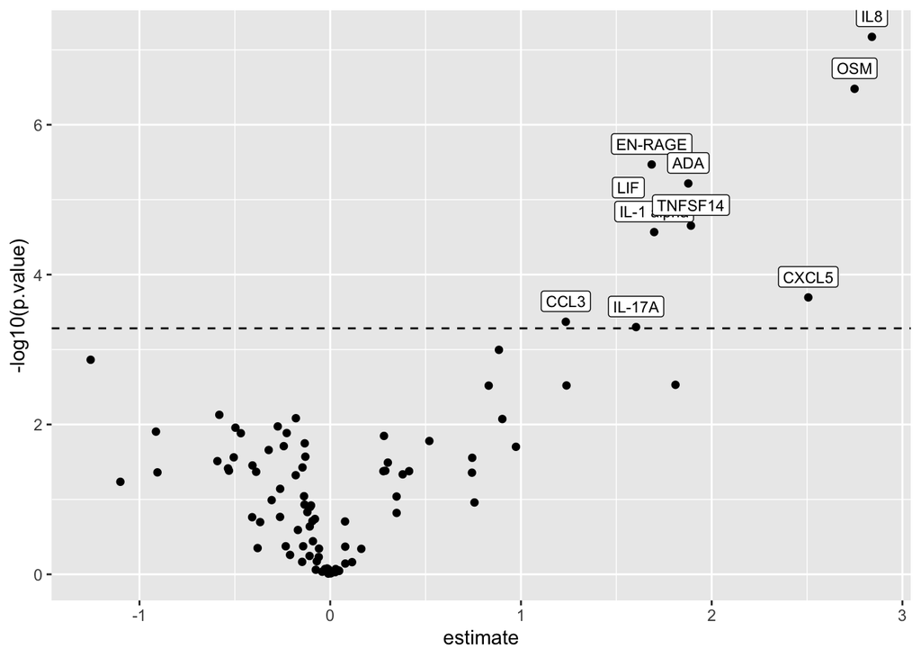

```
>
> $`pleural-16x-dilution01.infect.bi.fulladj`
```

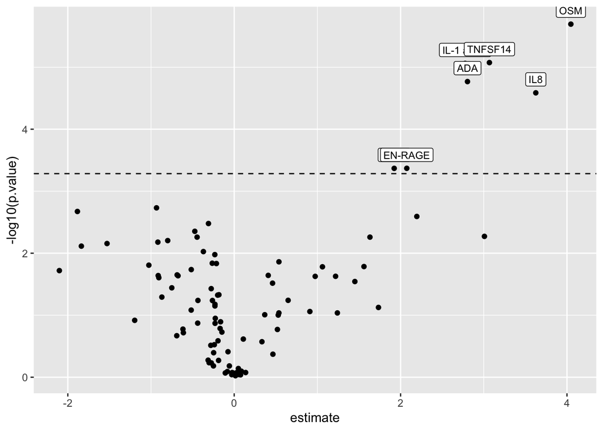

```
>
> $`pleural-16x-dilution01.comp.out.fulladj`
```

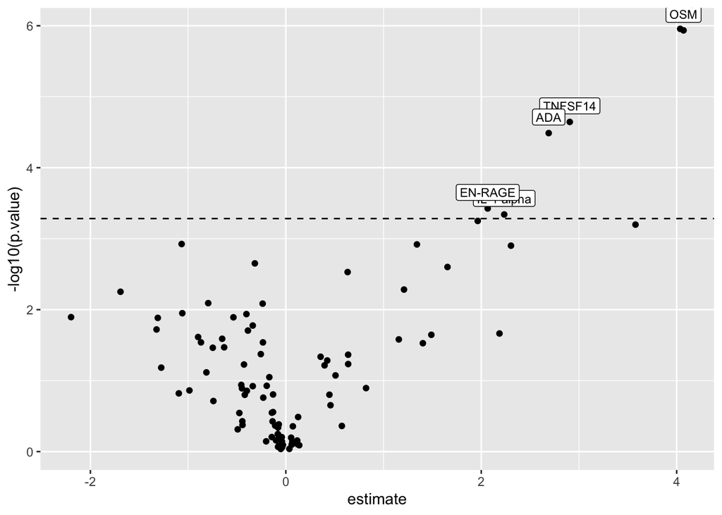

```
>
> $`pleural-16x-dilution01.infect.bi.new.fulladj`
```

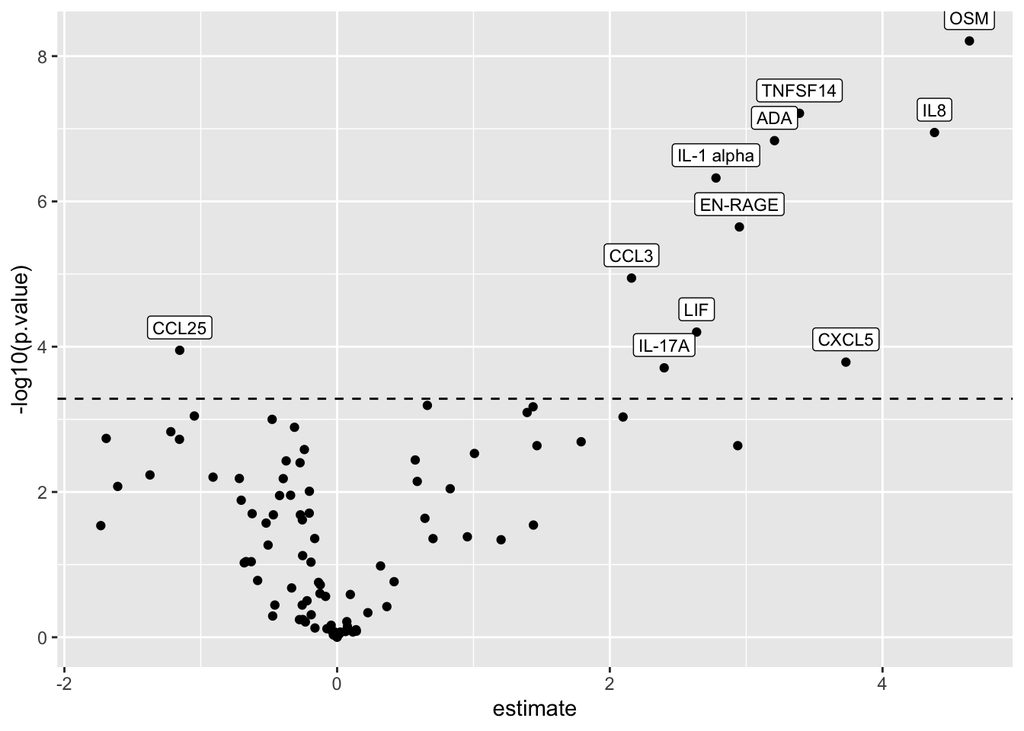